# Chapter 4 SR

2022-10-02

```r
library(tidyverse)
library(rethinking)
library(tidybayes)
library(splines)
```

## Question 1

Question 1 asked which of these lines is the likelihood. According to the chapter, it would be the first line yi ∼ Normal(µ, σ) because the latter two are priors.

## QUestion 2

There are two parameters, that is the prior for µ and σ

## Question 3

$$\begin {aligned}
Pr(\mu, \sigma | y) = \frac{\prod_{i}^{} Normal(y_i | \mu,
\sigma)Normal(\mu|0, 10)Exponential(\sigma|1)}
{\int \int \prod_{i}^{} Normal(y_i | \mu,
\sigma)Normal(\mu|0, 10)Exponential(\sigma|1) d\mu d\sigma}
\end{aligned}$$

## Question 4

This question asked for the linear model. In this instance it would be second line, as the first is the likelihood and the third through fifth is the priors.

## Question 5

As explained above, there are three parameters.

## Question 1

This question just asks us to simulate a prior prediction. All we have to do is now generate the data

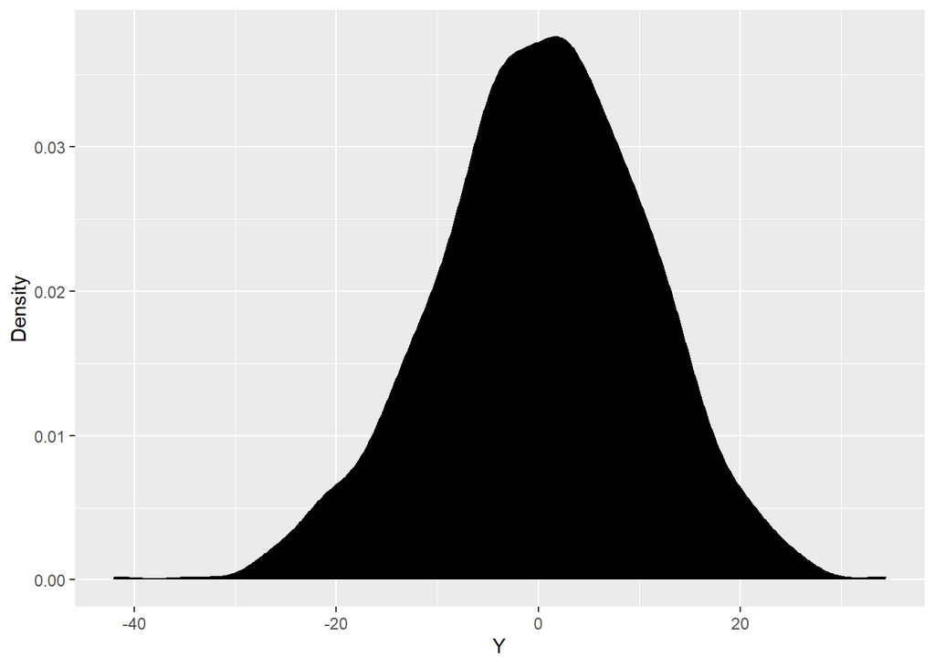

```r
set.seed(15)

sample_data <-
  tibble(
  a = rnorm(n = 1000, mean = 0, sd = 10),
  b = rexp(n = 1000, rate = 1),
  y = rnorm(n = 1000, mean = a, sd = b),
)
#plot
sample_data %>%
  ggplot(aes(x = y)) +
  geom_density(fill = "black") +
  labs(x = "Y", y = "Density")
```

## Question 2

The next question asks us to translate it into a quap formula.

```r
flist <- alist(mu = rnorm(0 , 10),
              sigma = rexp(1),
              y = rnorm( mu, sigma))
```

##Question 3

Question three asks us to turn it into a mathmatical model
$$\begin{aligned}
y &\sim \text{Normal}(\mu, \sigma) \\
\mu &= \alpha + \beta x \\
\alpha &\sim \text{Normal}(0, 10) \\
\beta &\sim \text{Uniform}(0, 1) \\
\sigma &\sim \text{Exponential}(1)
\end{aligned}$$

## Question 4

It is relatively reasonable to assume that height is normally distributed, as evidenced by our conversation in class.

$$\begin{aligned}
h_i &\sim \text{Normal}(\mu, \sigma) \\
\mu &= \alpha + \beta * x_i \\
\alpha &\sim \text{Normal}(164, 20) \\
\beta &\sim \text{LogNormal}(0, 1) \\
\sigma &\sim \text{Uniform}(0,30)
\end{aligned}$$

## Question 5

This wouldn’t really change my analysis, as Log Normal already forced a positive growth rate.

## QUestion 6

Mcelreath has informed that that there must never more than a variance of 64, As the variance is a square of sigma. It means that this must be the prior.
$$\begin{aligned}
\sigma &\sim \text{Uniform}(0,8)
\end{aligned}$$
as 8^2 =64.

## Question 7

Mcelreath wants us to look back at m4.3

```r
data("Howell1")
d1 <- Howell1

d1 <- d1 %>%
  filter(age >= 18) %>%
  mutate(weight_c = weight - mean(weight))
```

```r
set.seed(15)
m4.3<- quap(
  alist(
      height ~ dnorm(mu, sigma),
      mu <- a + b * weight_c,
      a ~ dnorm(178, 20),
      b ~ dlnorm(0, 1),
      sigma ~ dunif(0, 50)
),
data = d1)

# without the centering
m4.3b<- quap(
  alist(
      height ~ dnorm(mu, sigma),
      mu <- a + b * weight,
      a ~ dnorm(178, 20),
      b ~ dlnorm(0, 1),
      sigma ~ dunif(0, 50)
  ),
  data = d1)
```

```r
round(diag(vcov(m4.3)), 3)
```

```
##     a     b sigma
## 0.073 0.002 0.037
```

```r
round(diag(vcov(m4.3b)), 3)
```

```
##     a     b sigma
## 3.602 0.002 0.037
```

The covariation rate of alpha was increased by not centering. In the original version, I had a value of .073, and had a value of 3.602 without centering.

If we look to if we look to the posterior predictions of both models we can see a little more.

```r
precis(m4.3)
```

```
##              mean         sd        5.5%      94.5%
## a     154.6028369 0.27035903 154.1707509 155.034923
## b       0.9032943 0.04193157   0.8362795   0.970309
## sigma   5.0728421 0.19124539   4.7671950   5.378489
```

```r
precis(m4.3b)
```

```
##              mean         sd        5.5%       94.5%
## a     114.5327952 1.89777919 111.4997775 117.5658128
## b       0.8907851 0.04175865   0.8240467   0.9575235
## sigma   5.0728120 0.19125764   4.7671453   5.3784787
```